# Introdução à Linguagem Julia

Julia é uma linguagem dinâmica de alto nível e alto desempenho. Ela se assemelha ao MatLab e ao Python na facilidade de escrita de código, mas sua velocidade pode ser comparável ao C e Fortran.

A versão mais atual do Julia é a **0.6**.

# Jupyter

O Jupyter é uma interface web para Julia, Python, e muitas outras. Ela **não** é o Julia, isto é, o Julia não depende do Jupyter para funcionar. No entanto, usando o Jupyter, aulas e apresentações ficam mais práticas.

Cada *célula* do Jupyter pode ser executada com um `ctrl+enter`, ou um `ctrl+shift`, sendo que o último move a seleção para a célula de baixo. Você pode adicionar novas células usando o `+` no topo da página.

# O REPL - Terminal Interativo

Ao abrir o Julia no Windows, ou digitar `julia` no terminal do Mac ou Linux, se abrirá um prompt tipo

```
julia>
```

O Jupyter também serve como esse prompt e todo comando digitado aqui pode ser digitado lá.

# Editor: JunoLab ou Atom

[JunoLab](http://junolab.org/) é o editor oficial de Julia. Ainda não está 100%, mas já está usável. Você pode usar outros editores, mas o suporte à caracteres especiais é quase que exclusivo de um punhado. Em especial, o JunoLab é um dos melhores para isso.

O JunoLab é feito em cima do [Atom](http://atom.io). Você pode baixar o Atom e instalar os pacotes específicos, se preferir ter mais controle.

## Jupyter vs Editor

O Jupyter é utilizado para aulas, apresentações, workshops. A parte importante é a interatividade.

O editor é usado para fazer códigos sérios. Para desenvolver os exercícios, projetos, e futuros pacotes, é necessário criar arquivos e ter um ambiente adequado.

```julia
srand(0) # Para controle pessoal. Ignorar
```

[output not shown]

# Básico

```julia
2 + 3
```

```
5
```

```julia
3 * 5
```

```
15
```

```julia
7 ^ 3
```

```
343
```

```julia
exp(2)
```

```
7.38905609893065
```

```julia
sin(3.14159/4)
```

```
0.7071063120935576
```

```julia
pi
```

```
π = 3.1415926535897...
```

```julia
sin(pi/4)
```

```
0.7071067811865475
```

```julia
round(1.2)
```

```
1.0
```

```julia
abs(-3)
```

```
3
```

```julia
x = 3
```

```
3
```

```julia
x ^ 2
```

```
9
```

```julia
y = 2x
```

```
6
```

```julia
y - x
```

```
3
```

```julia
1e-2 # 10⁻²
```

```
0.01
```

```julia
1e3 # 10³
```

```
1000.0
```

```julia
0.1 + 0.2 - 0.3
```

```
5.551115123125783e-17
```

# Álgebra Linear Numérica

```julia
rand(3)
```

```
3-element Array{Float64,1}:
 0.823648
 0.910357
 0.164566
```

```julia
ones(3)
```

```
3-element Array{Float64,1}:
 1.0
 1.0
 1.0
```

```julia
zeros(3)
```

```
3-element Array{Float64,1}:
 0.0
 0.0
 0.0
```

```julia
rand(2,4)
```

```
2×4 Array{Float64,2}:
 0.177329  0.203477   0.0682693  0.973216
 0.27888   0.0423017  0.361828   0.585812
```

```julia
v = rand(3)
```

```
3-element Array{Float64,1}:
 0.539289
 0.260036
 0.910047
```

```julia
A = rand(2, 3)
```

```
2×3 Array{Float64,2}:
 0.167036  0.575887  0.9678
 0.655448  0.868279  0.76769
```

```julia
A * v
```

```
2-element Array{Float64,1}:
 1.12057
 1.27789
```

```julia
w = rand(2)
```

```
2-element Array{Float64,1}:
 0.469304
 0.0623676
```

```julia
A' * w
```

```
3-element Array{Float64,1}:
 0.119269
 0.324419
 0.502071
```

```julia
B = rand(2, 3)
```

```
2×3 Array{Float64,2}:
 0.353129  0.043141  0.0668464
 0.767602  0.267985  0.156637
```

```julia
A + B
```

```
2×3 Array{Float64,2}:
 0.520165  0.619028  1.03465
 1.42305   1.13626   0.924327
```

```julia
A * B'
```

```
2×2 Array{Float64,2}:
 0.148524  0.434139
 0.320233  0.856057
```

```julia
A' * B
```

```
3×3 Array{Float64,2}:
 0.562109  0.182856  0.113833
 0.869855  0.25753   0.1745
 0.931038  0.247481  0.184942
```

```julia
A = rand(3, 3)
b = rand(3)
x = A\b # Resolve o SL
```

```
3-element Array{Float64,1}:
  0.977784
 -0.704457
  0.734381
```

```julia
A * x - b # É pra ser zero (ou quase)
```

```
3-element Array{Float64,1}:
 -2.77556e-17
  1.11022e-16
  0.0
```

```julia
norm(A*x-b) # norm = ‖ ⋅ ‖
```

```
1.1443916996305594e-16
```

```julia
v = [1.0; 2.0; 3.0]
w = [2.0; -2.0; 2.0]
dot(v, w) # ⟨v,w⟩
```

```
4.0
```

```julia
det(A)
```

```
0.2801734907127258
```

```julia
A^2 # A * A
```

```
3×3 Array{Float64,2}:
 0.590834  0.914645  0.870025
 0.765794  0.768688  0.861552
 1.27754   1.56322   1.29784
```

```julia
A .^ 2 # Cada elemento de A ao quadrado
```

```
3×3 Array{Float64,2}:
 0.366384   0.836698  0.0143167
 0.0184266  0.090045  0.588396
 0.702441   0.522512  0.643081
```

```julia
B = rand(3, 3)
```

```
3×3 Array{Float64,2}:
 0.951691  0.114269   0.104823
 0.801119  0.0795545  0.838075
 0.124323  0.776674   0.184115
```

```julia
A .* B
```

```
3×3 Array{Float64,2}:
 0.576055  0.104523   0.0125423
 0.108747  0.0238723  0.642862
 0.104197  0.561419   0.147646
```

## Acesso aos elementos

```julia
v
```

```
3-element Array{Float64,1}:
 1.0
 2.0
 3.0
```

```julia
v[1]
```

```
1.0
```

```julia
v[2]
```

```
2.0
```

```julia
A
```

```
3×3 Array{Float64,2}:
 0.605297  0.914712  0.119653
 0.135745  0.300075  0.76707
 0.838118  0.72285   0.801924
```

```julia
A[1,1]
```

```
0.6052967398293401
```

```julia
A[2,3]
```

```
0.7670696322682211
```

```julia
v[1:2]
```

```
2-element Array{Float64,1}:
 1.0
 2.0
```

```julia
A[:,2]
```

```
3-element Array{Float64,1}:
 0.914712
 0.300075
 0.72285
```

```julia
A[1,:]
```

```
3-element Array{Float64,1}:
 0.605297
 0.914712
 0.119653
```

```julia
A[2,3] = 0.0
```

```
0.0
```

```julia
A
```

```
3×3 Array{Float64,2}:
 0.605297  0.914712  0.119653
 0.135745  0.300075  0.0
 0.838118  0.72285   0.801924
```

```julia
eye(3)
```

```
3×3 Array{Float64,2}:
 1.0  0.0  0.0
 0.0  1.0  0.0
 0.0  0.0  1.0
```

```julia
m, n = size(A)
```

```
(3, 3)
```

```julia
length(v)
```

```
3
```

## Matriz por blocos - concatenação

```julia
[rand(3,3) zeros(3,2); ones(2,3) eye(2,2)]
```

```
5×5 Array{Float64,2}:
 0.312145  0.654922  0.735004  0.0  0.0
 0.196407  0.586712  0.548342  0.0  0.0
 0.873581  0.632696  0.476883  0.0  0.0
 1.0       1.0       1.0       1.0  0.0
 1.0       1.0       1.0       0.0  1.0
```

# Funções

```julia
f(x) = x^2
f(2)
```

```
4
```

```julia
f(-3)
```

```
9
```

```julia
g(a,b) = exp(a + b)
```

```
g (generic function with 1 method)
```

```julia
g(2,3)
```

```
148.4131591025766
```

```julia
g(3,-3)
```

```
1.0
```

```julia
h = x -> sin(x)
```

```
(::#3) (generic function with 1 method)
```

```julia
h(2)
```

```
0.9092974268256817
```

```julia
function aprox_der(f, a, h)
    (f(a+h) - f(a))/h
end
```

```
aprox_der (generic function with 1 method)
```

```julia
aprox_der(h, pi/6, 1e-8)
```

```
0.8660254013914681
```

```julia
function aprox_der(f, a, h = 1e-8)
    (f(a+h) - f(a))/h
end
```

```
aprox_der (generic function with 2 methods)
```

```julia
aprox_der(h, pi/6)
```

```
0.8660254013914681
```

```julia
aprox_der(x->x^2+3x+2, 2) # 2x + 3 com x = 2: 7
```

```
6.999999868639861
```

### Exercício

Escreva uma função usando `function` que recebe uma função `f`, um valor `a`, um valor `b`, e retorna `a * f(b)`.

## Vetor vs Array vs Array 1xN vs Array Nx1

```julia
ones(3)
```

```
3-element Array{Float64,1}:
 1.0
 1.0
 1.0
```

```julia
[1.0 1.0 1.0]
```

```
1×3 Array{Float64,2}:
 1.0  1.0  1.0
```

```julia
[1.0; 1.0; 1.0]
```

```
3-element Array{Float64,1}:
 1.0
 1.0
 1.0
```

```julia
[1.0, 1.0, 1.0]
```

```
3-element Array{Float64,1}:
 1.0
 1.0
 1.0
```

```julia
[1.0 1.0 1.0]'
```

```
3×1 Array{Float64,2}:
 1.0
 1.0
 1.0
```

```julia
ones(3)'
```

```
1×3 RowVector{Float64,Array{Float64,1}}:
 1.0  1.0  1.0
```

```julia
ones(3)''
```

```
3-element Array{Float64,1}:
 1.0
 1.0
 1.0
```

# Exercícios

1. Crie um vetor aleatório e mude o primeiro elemento para o seu oposto (i.e. mude o sinal)
2. Crie um vetor com os ângulos importantes: 0, pi/6, pi/4, pi/3 e pi/2.
3. Crie um vetor com o seno de cada ângulo e outro com o cosseno, usando o vetor acima.
4. Calcule a tangente de cada angulo usando os dois vetores acima (tan = sen/cos)
5. Crie uma função que recebe uma matriz A e um vetor v e retorna $\dfrac{\langle v, Av\rangle}{\langle v, v\rangle}$

# Loops e condicionais

```julia
collect(1:5)
```

```
5-element Array{Int64,1}:
 1
 2
 3
 4
 5
```

```julia
collect(1:2:5)
```

```
3-element Array{Int64,1}:
 1
 3
 5
```

```julia
collect(0.0:0.1:1.0)
```

```
11-element Array{Float64,1}:
 0.0
 0.1
 0.2
 0.3
 0.4
 0.5
 0.6
 0.7
 0.8
 0.9
 1.0
```

```julia
collect(linspace(0, 1, 10))
```

```
10-element Array{Float64,1}:
 0.0
 0.111111
 0.222222
 0.333333
 0.444444
 0.555556
 0.666667
 0.777778
 0.888889
 1.0
```

```julia
collect(10:-1:1)
```

```
10-element Array{Int64,1}:
 10
  9
  8
  7
  6
  5
  4
  3
  2
  1
```

```julia
for i = 2.0:0.5:3.0
    println(i^2) # Impressão e quebra linha
end
```

```
4.0
6.25
9.0
```

```julia
?println
```

```
search: println print_with_color print print_shortest sprint @printf isprint
```

```
println(io::IO, xs...)
```

Print (using `print`) `xs` followed by a newline. If `io` is not supplied, prints to `STDOUT`.

```julia
for i = 1:10
    print(i)
end
```

```
12345678910
```

```julia
for i = 1:10
    println("i = $i")
end
```

```
i = 1
i = 2
i = 3
i = 4
i = 5
i = 6
i = 7
i = 8
i = 9
i = 10
```

```julia
for i = 1:10
    @printf("i = %03d\n", i) # Notação de C
end
```

```
i = 001
i = 002
i = 003
i = 004
i = 005
i = 006
i = 007
i = 008
i = 009
i = 010
```

```julia
x = rand(10)
y = zeros(10)
for i = 1:10
    y[i] = x[i] * i
end
```

```julia
y ./ x
```

```
10-element Array{Float64,1}:
  1.0
  2.0
  3.0
  4.0
  5.0
  6.0
  7.0
  8.0
  9.0
 10.0
```

```julia
for x in [0; pi/6; pi/4; pi/3; pi/2]
    println("sin($x) = $(sin(x))")
end
```

```
sin(0.0) = 0.0
sin(0.5235987755982988) = 0.49999999999999994
sin(0.7853981633974483) = 0.7071067811865475
sin(1.0471975511965976) = 0.8660254037844386
sin(1.5707963267948966) = 1.0
```

```julia
for i = 3:3:20
    print("$i ")
end
```

```
3 6 9 12 15 18
```

```julia
for i in 3:2:10
    println("$i^2 = $(i^2)")
end
```

```
3^2 = 9
5^2 = 25
7^2 = 49
9^2 = 81
```

```julia
Float64[2; 3]
```

```
2-element Array{Float64,1}:
 2.0
 3.0
```

```julia
for x in Any["a", 0, 3.14, e, 3//4, im, ones(2), ones(2,2)]
    println("x: $x    Tipo: $(typeof(x))")
end
```

```
x: a    Tipo: String
x: 0    Tipo: Int64
x: 3.14    Tipo: Float64
x: e = 2.7182818284590...    Tipo: Irrational{:e}
x: 3//4    Tipo: Rational{Int64}
x: im    Tipo: Complex{Bool}
x: [1.0, 1.0]    Tipo: Array{Float64,1}
x: [1.0 1.0; 1.0 1.0]    Tipo: Array{Float64,2}
```

```julia
n = 6
v = ones(n)
v[n/2] = 2
v
```

```
ArgumentError: invalid index: 3.0

Stacktrace:
 [1] setindex!(::Array{Float64,1}, ::Int64, ::Float64) at ./abstractarray.jl:967
 [2] include_string(::String, ::String) at ./loading.jl:515
```

```julia
n/2
```

```
3.0
```

```julia
div(n,2)
```

```
3
```

```julia
round(Int, n/2)
```

```
3
```

```julia
10 % 4 # Resto da divisão de 10 por 4
```

```
2
```

**Fatorial**: $ n! = n(n-1)\dots2. 1 $

```julia
function fatorial(n)
    resultado = 1
    for i = 1:n
        resultado = resultado * i
    end
    return resultado
end
```

```
fatorial (generic function with 1 method)
```

```julia
fatorial(4)
```

```
24
```

```julia
fatorial(5)
```

```
120
```

```julia
fatorial(0)
```

```
1
```

```julia
fatorial(4.3)
```

```
24.0
```

```julia
fatorial(-2)
```

```
1
```

```julia
function fatorial2(n :: Int)
    resultado = 1
    for i = 1:n
        resultado = resultado * i
    end
    return resultado
end
```

```
fatorial2 (generic function with 1 method)
```

```julia
fatorial2(3.4)
```

```
MethodError: no method matching fatorial2(::Float64)
Closest candidates are:
  fatorial2(::Int64) at In[102]:2

Stacktrace:
 [1] include_string(::String, ::String) at ./loading.jl:515
```

**sinal**: $ \mbox{sinal}(x) = \left\{\begin{array}{rl} 1, & x > 0 \\ -1, & x < 0 \\ 0, & x = 0. \end{array}\right.$

```julia
function sinal(x)
    if x > 0
        return 1
    elseif x < 0
        return -1
    else
        return 0
    end
end
```

```
sinal (generic function with 1 method)
```

```julia
sinal(3.2)
```

```
1
```

```julia
sinal(-1.2)
```

```
-1
```

```julia
sinal(0.0)
```

```
0
```

**Bháskara:** $ax^2 + bx + c = 0$ e $b^2 - 4ac \geq 0$ implicam em $x = \dfrac{-b \pm \sqrt{b^2 - 4ac}}{2a}. $

```julia
function bhaskara(a, b, c)
    Δ = b^2 - 4 * a * c
    if Δ < 0
        error("Nos reais não tem solução")
    end
    return (-b + sqrt(Δ)) / 2a, (-b - sqrt(Δ)) / 2a
end
```

```
bhaskara (generic function with 1 method)
```

```julia
bhaskara(1, 0, -1)
```

```
(1.0, -1.0)
```

```julia
bhaskara(1, 0, 1)
```

```
Nos reais não tem solução

Stacktrace:
 [1] bhaskara(::Int64, ::Int64, ::Int64) at ./In[108]:4
 [2] include_string(::String, ::String) at ./loading.jl:515
```

```julia
bhaskara(1, 0, -1)
```

```
(1.0, -1.0)
```

```julia
bhaskara(0, 1, 1)
```

```
(NaN, -Inf)
```

**MMC:** $\mbox{mmc}(a, b)$ é o menor número natural que é múltiplo de $a$ e de $b$.

```
or -> ||
and -> &&
```

```julia
function mmc(a::Int, b::Int)
    if a < 1 || b < 1
        error("Entrada deve ser de dois inteiros positivos")
    end
    x = 1
    while a > 1 || b > 1
        achou = false
        for j = 2:max(a,b)
            if a % j == 0 || b % j == 0
                x = x * j
                achou = true
            end
            if a % j == 0
                a = div(a, j)
            end
            if b % j == 0
                b = div(b, j)
            end
            if achou
                break
            end
        end
    end
    return x
end
```

```
mmc (generic function with 1 method)
```

```julia
mmc(2,3)
```

```
6
```

```julia
mmc(5, 7)
```

```
35
```

```julia
mmc(6, 8)
```

```
24
```

```julia
mmc(12, 14)
```

```
84
```

```julia
mmc(-1, 0)
```

```
Entrada deve ser de dois inteiros positivos

Stacktrace:
 [1] mmc(::Int64, ::Int64) at ./In[113]:3
 [2] include_string(::String, ::String) at ./loading.jl:515
```

```julia
mmc(2.0, 3.0)
```

```
MethodError: no method matching mmc(::Float64, ::Float64)

Stacktrace:
 [1] include_string(::String, ::String) at ./loading.jl:515
```

## Exercício

- Atualize a função fatorial para proibir números negativos não inteiros. Proíba também o fatorial de um número maior que 21.
- Atualize a função de Bháskara para que retorne um erro caso $a$ seja 0.
- Faça uma função que recebe um inteiro `n` e verifica se ele é primo.

## Arquivos

A aula de arquivos deve ser feira fora do Jupyter para melhor entendimento. Use:

- Atom/JunoLab para edição;
- o terminal do Julia.

Dentro do terminal, use

```
include("arquivo.jl")
```

para incluir um arquivo e rodar todo seu conteúdo.

O arquivo precisa estar na mesma pasta. Se não estiver você tem duas opções:

- Navegar até a pasta corresponde, usando o comando `cd`; ou
- incluir o arquivo passando o caminho inteiro: `include("~/Desktop/arquivo.jl")`. (`~` em Linux quer dizer diretório pessoal padrão - em geral `/home/fulano/`.

## Pacotes

O Julia não vem com tudo pré-instalado, assim como a maioria das linguagem de programação. Para encontrar um pacote que faça o que você quer, você pode buscar na lista http://pkg.julialang.org/ ou no Google.

### Instalação de pacotes

Caso o pacote que você encontrou seja indexado, basta usar o comando `Pkg.add("Pacote")`. A indexação depende do criador do pacote. Os principais pacotes estão indexados. Por exemplo:

- Pacote `Plots`: comandos unificados de fazer gráficos.
- Pacote `PyPlot`: para desenhar gráficos usando o `matplotlib`. Bonito, mas lento e demorado de instalar.
- Pacote `GR`: outro pacote para desenhar gráficos. Mais rápido, mas menos bonito.
- Pacote `Primes`: pacote para trabalhar com números primos.
- Pacote `Combinatorics`: pacote para funções de combinátoria.

Caso o pacote não esteja indexado, ainda é possível instalá-lo, usando os comandos `Pkg.clone` e `Pkg.build`.

## Plots

Utilizaremos os pacotes `Plots` e `PyPlot` para fazer nossos gráficos. Caso prefira o `GR`, mude o comando `pyplot` logo abaixo por `gr`.

Para o help dos gráficos, veja [Julia Plots](https://juliaplots.github.io).

```julia
using Plots
pyplot(size=(400,300)) # ou gr()
```

```
WARNING: using Plots.h in module Main conflicts with an existing identifier.
WARNING: using Plots.w in module Main conflicts with an existing identifier.
WARNING: Compat.UTF8String is deprecated, use String instead.
  likely near In[120]:68
```

```
Plots.PyPlotBackend()
```

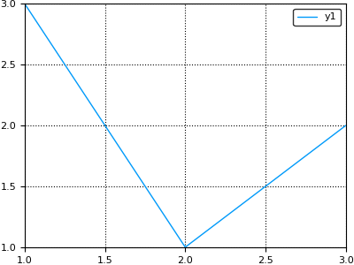

```julia
plot([1; 2; 3], [3; 1; 2]) # plot(x, y)
```

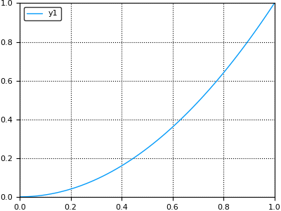

```julia
x = linspace(0, 1, 100) # 100 elementos igual. esp. de 0 a 1
y = x.^2
plot(x, y)
```

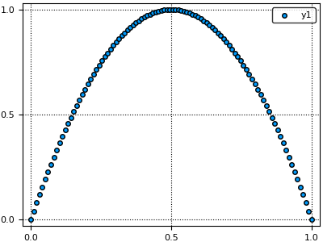

```julia
scatter(x, 4 * x .* (1 - x))
```

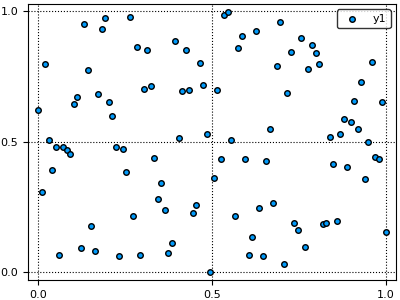

```julia
scatter(x, rand(100))
```

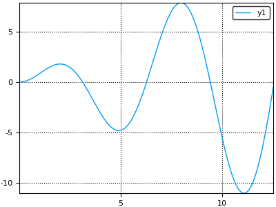

```julia
f(x) = x * sin(x)
plot(f, 0, 4pi) # plot(f, a, b)
```

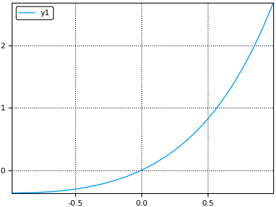

```julia
plot(x->exp(x) * x, -1, 1)
```

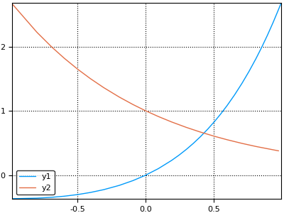

```julia
plot!(x->exp(-x), -1, 1)
```

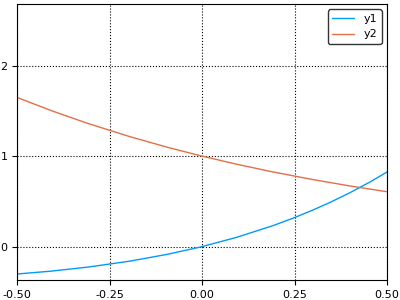

```julia
xlims!(-0.5, 0.5)
```

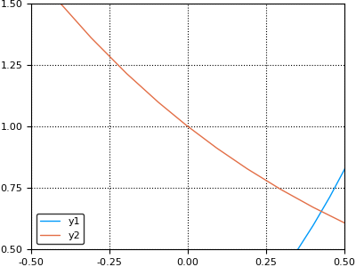

```julia
ylims!(0.5, 1.5)
```

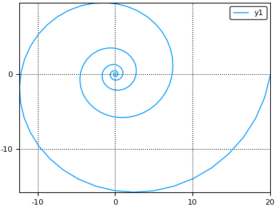

```julia
t = linspace(-2, 3, 200)
x = cos.(t*pi*2) .* exp.(t)
y = sin.(t*pi*2) .* exp.(t)
plot(x, y)
```

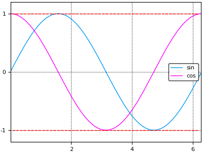

```julia
plot(sin, 0, 2pi, label="sin")
plot!(cos, 0, 2pi, label="cos", c = :magenta)
plot!(x->1, 0, 2pi, c=:red, l=:dash, label="")
plot!(x->-1, 0, 2pi, c=:red, l=:dash, label="")
ylims!(-1.2, 1.2)
```

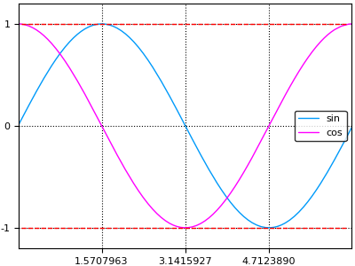

```julia
xticks!(0:pi/2:2pi)
```

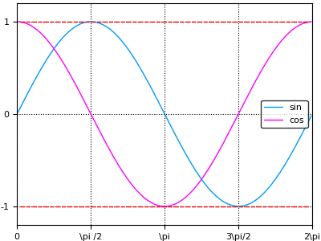

```julia
xticks!(0:pi/2:2pi, ["0", "\\pi /2", "\\pi", "3\\pi/2", "2\\pi"])
```

```julia
x = linspace(0, 2*pi, 100)
anim = Animation()
for i = 1:5:100
    plot(x[1:i], sin.(x[1:i]))
    frame(anim)
end
gif(anim, "exemplo.gif", fps=10)
```

```
INFO: Saved animation to /home/abel/disciplinas/cm103/material/exemplo.gif
```

[figure not shown]

```julia
x = linspace(0, 2*pi, 100)
anim = Animation()
for i = 1:3:100
    plot(x[1:i], sin.(x[1:i]))
    xlims!(x[1], x[end])
    ylims!(-1, 1)
    frame(anim)
end
gif(anim, "exemplo2.gif", fps=12)
```

```
INFO: Saved animation to /home/abel/disciplinas/cm103/material/exemplo2.gif
```

[figure not shown]

```julia
x = linspace(0, 2*pi, 100)
anim = Animation()
for i = 1:3:100
    plot(x, sin.(x), leg=false)
    a = x[i]
    scatter!([a], [sin(a)], c=:red)
    plot!(x, sin(a) + cos(a)*(x-a), c=:red, l=:dash)
    xlims!(x[1], x[end])
    ylims!(-2, 2)
    frame(anim)
end
gif(anim, "exemplo3.gif", fps=12)
```

```
INFO: Saved animation to /home/abel/disciplinas/cm103/material/exemplo3.gif
```

[figure not shown]

## Exercícios

1. Crie uma função que resolve $ax^2 + bx + c = 0$ por Bháskara, mas se $\Delta < 0$, ele retorna as soluções complexas.
2. Faça uma função para calcular o máximo dividor comum de dois números inteiros positivos.
3. Crie um vetor x aleatório, e crie y = 2x + 3. Crie um plot e depois um scatter de x vs y. Qual a diferença?
4. Faça o gráfico de $e^x$ no intervalo [-1,1] em vermelho.
5. Faça no mesmo gráfico os gráficos de $1$, $1+x$ e $1+x+0.5x^2$ em azul, com linha pontilhada.